# Proyecto Final

Mariel Chaveste

2023-06-14

### Importación de los Datos

En este apartado se declaran los data frame’s

```r
infoHeroes <- read.csv("Data/heroesInformation.csv", na.strings = c("-", "-99", "-99.0"))
infoStats <- read.csv("Data/charactersStats.csv", na.strings = "")
colnames(infoHeroes)[2] <- "Name"
DC_Marvel <- infoHeroes %>%
  filter(infoHeroes$Publisher %in% c("DC Comics", "Marvel Comics"))
DC_Marvel <- DC_Marvel %>%
  filter(!duplicated(Name))
Dc_Marvel_StatsInfo <- left_join(DC_Marvel, infoStats, by = "Name")
```

### Manipulación de la base de datos Dc_Marvel_StatsInfo

Se realiza un descarte de variables y chequeo, así como la completación de valores faltantes tanto de tipo caracter como numérico.

```r
Dc_Marvel_StatsInfo <- Dc_Marvel_StatsInfo[-390,-c(1,9,12)]

Dc_Marvel_StatsInfo$Race[is.na(Dc_Marvel_StatsInfo$Race)] <- "Undefined"
Dc_Marvel_StatsInfo$Eye.color[is.na(Dc_Marvel_StatsInfo$Eye.color)] <- "Undefined"
Dc_Marvel_StatsInfo$Alignment.x[is.na(Dc_Marvel_StatsInfo$Alignment.x)] <- "Undefined"
Dc_Marvel_StatsInfo$Hair.color[is.na(Dc_Marvel_StatsInfo$Hair.color)] <- "Undefined"
Dc_Marvel_StatsInfo$Gender[is.na(Dc_Marvel_StatsInfo$Gender)] <- "Undefined"
NamesM <- as.vector(Dc_Marvel_StatsInfo[,1])
row.names(Dc_Marvel_StatsInfo) <- NamesM
Dc_Marvel_StatsInfo <- Dc_Marvel_StatsInfo[,-1]
```

Gráficos para identificar las variables numéricas faltantes. Y observamos que las más incompletas son “Weight” y “Height”.

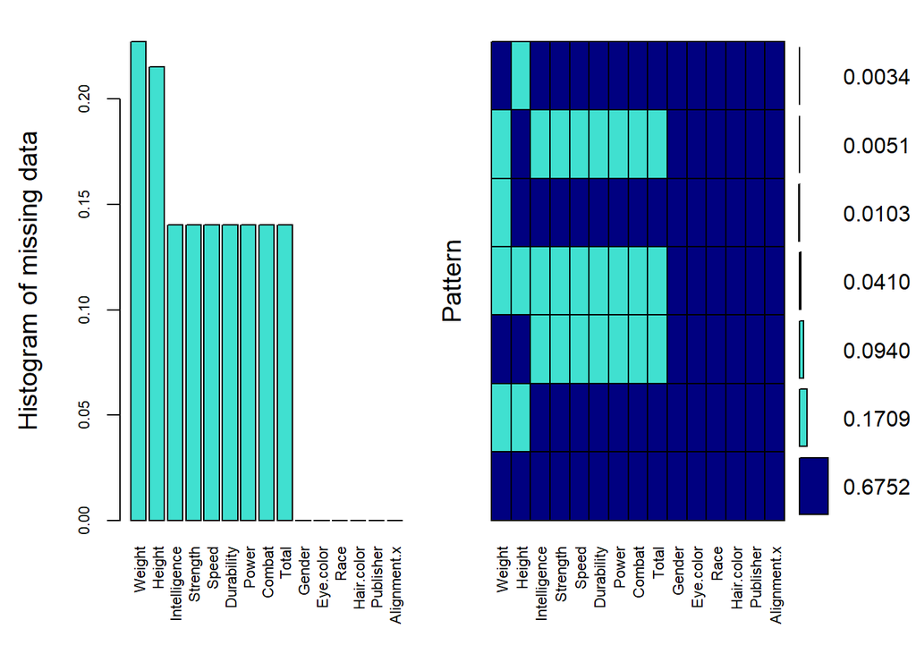

```
##
##  Variables sorted by number of missings:
##      Variable     Count
##        Weight 0.2273504
##        Height 0.2153846
##  Intelligence 0.1401709
##      Strength 0.1401709
##         Speed 0.1401709
##    Durability 0.1401709
##         Power 0.1401709
##        Combat 0.1401709
##         Total 0.1401709
##        Gender 0.0000000
##     Eye.color 0.0000000
##          Race 0.0000000
##    Hair.color 0.0000000
##     Publisher 0.0000000
##   Alignment.x 0.0000000
```

```r
aggr_plot <- aggr(Dc_Marvel_StatsInfo, col=c('navyblue','turquoise'), numbers=TRUE, sortVars=TRUE, labels=names(Dc_Marvel_StatsInfo),
                  cex.axis=.7, gap=3, ylab=c("Histogram of missing data","Pattern"))
```

Se realiza la imputación de los datos incompletos y evalúa la calidad de los datos imputados para las variables numéricas previamente mencionadas a través de gráficas de densidad.

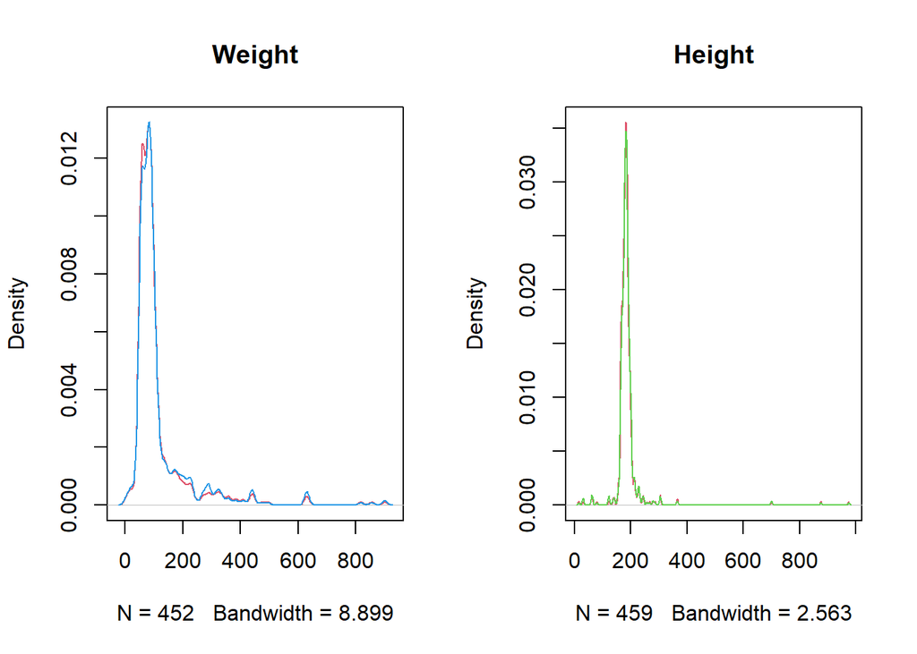

```r
columns1 <- c("Weight", "Height")
imputed_data <- mice(Dc_Marvel_StatsInfo[,names(Dc_Marvel_StatsInfo) %in% columns1],m = 1,
                     maxit = 1, method = "midastouch",seed = 2018,print=F)
complete.data <- mice::complete(imputed_data)

par(mfrow=c(1,2))
plot(density(Dc_Marvel_StatsInfo$Weight,na.rm = T),col=2,main="Weight")
lines(density(complete.data$Weight),col=4)
plot(density(Dc_Marvel_StatsInfo$Height,na.rm = T),col=2,main="Height")
lines(density(complete.data$Height),col=3)
```

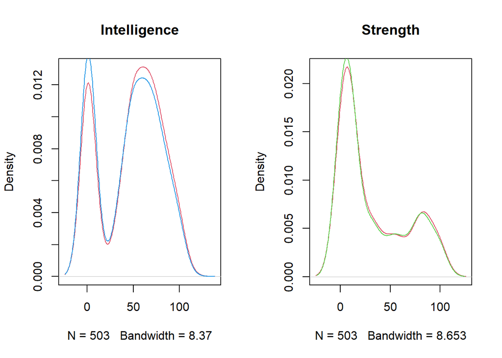

```r
columns2 <- c("Intelligence", "Strength", "Speed", "Durability", "Power", "Combat")
imputed_data2 <- mice(Dc_Marvel_StatsInfo[,names(Dc_Marvel_StatsInfo) %in% columns2],m = 1,
                     maxit = 1, method = "rf",seed = 2018,print=F)
complete.data2 <- mice::complete(imputed_data2)

par(mfrow=c(1,2))
plot(density(Dc_Marvel_StatsInfo$Intelligence,na.rm = T),col=2,main="Intelligence")
lines(density(complete.data2$Intelligence),col=4)
plot(density(Dc_Marvel_StatsInfo$Strength,na.rm = T),col=2,main="Strength")
lines(density(complete.data2$Strength),col=3)
```

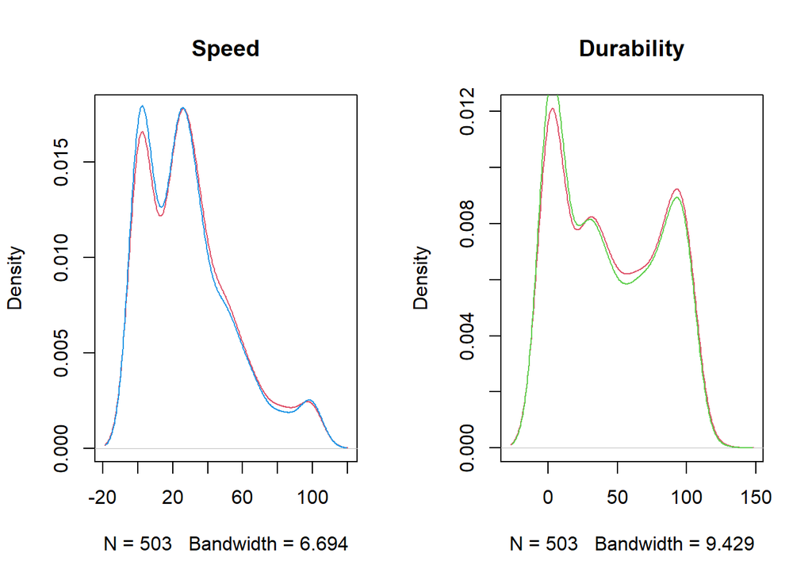

```r
par(mfrow=c(1,2))
plot(density(Dc_Marvel_StatsInfo$Speed,na.rm = T),col=2,main="Speed")
lines(density(complete.data2$Speed),col=4)
plot(density(Dc_Marvel_StatsInfo$Durability,na.rm = T),col=2,main="Durability")
lines(density(complete.data2$Durability),col=3)
```

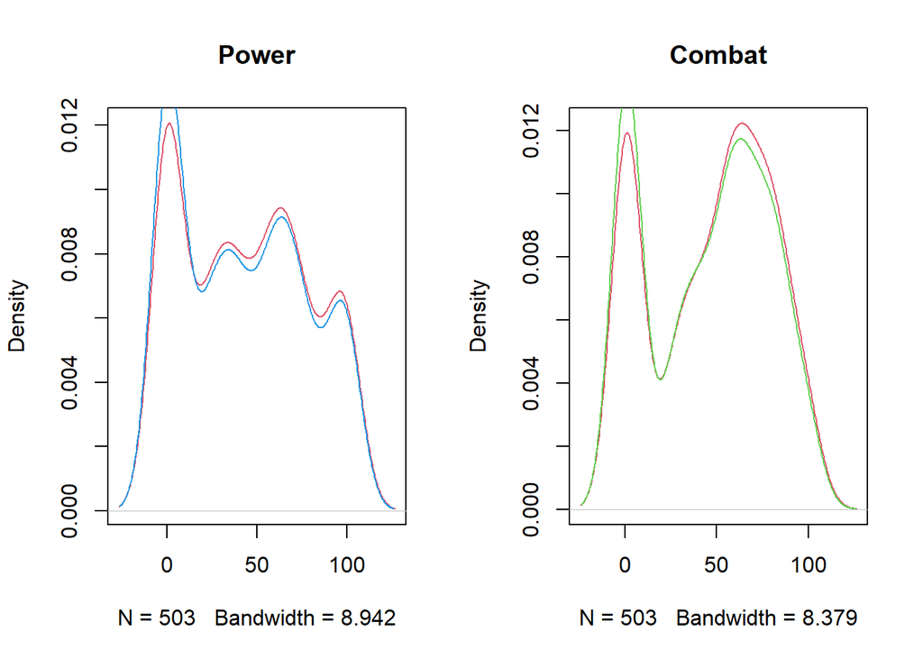

```r
par(mfrow=c(1,2))
plot(density(Dc_Marvel_StatsInfo$Power,na.rm = T),col=2,main="Power")
lines(density(complete.data2$Power),col=4)
plot(density(Dc_Marvel_StatsInfo$Combat,na.rm = T),col=2,main="Combat")
lines(density(complete.data2$Combat),col=3)
```

En la siguiente sección de código se implementan los datos imputados en los datos faltantes del data frame Dc_Marvel_StatsInfo para finalmente declarar el data frame Marvel_StatsInfo con el que se realizará el análisis estadístico.

```r
#md.pattern(Dc_Marvel_StatsInfo, rotate.names = T)

Dc_Marvel_StatsInfo$Weight <- complete.data$Weight
Dc_Marvel_StatsInfo$Height <- complete.data$Height
Dc_Marvel_StatsInfo$Intelligence <- complete.data2$Intelligence
Dc_Marvel_StatsInfo$Strength <- complete.data2$Strength
Dc_Marvel_StatsInfo$Speed <- complete.data2$Speed
Dc_Marvel_StatsInfo$Durability <- complete.data2$Durability
Dc_Marvel_StatsInfo$Power <- complete.data2$Power
Dc_Marvel_StatsInfo$Combat <- complete.data2$Combat


for (i in 1:nrow(Dc_Marvel_StatsInfo)) {
  Dc_Marvel_StatsInfo$Total[i] <- sum(Dc_Marvel_StatsInfo[,c("Intelligence", "Strength", "Speed", "Durability", "Power", "Combat")][i,])
}

Marvel_StatsInfo <- Dc_Marvel_StatsInfo %>%
  filter(Publisher == "Marvel Comics")
head(Marvel_StatsInfo)
```

```
##               Gender Eye.color              Race Hair.color Height
## A-Bomb          Male    yellow             Human    No Hair    203
## Abomination     Male     green Human / Radiation    No Hair    203
## Abraxas         Male      blue     Cosmic Entity      Black    203
## Absorbing Man   Male      blue             Human    No Hair    193
## Agent 13      Female      blue         Undefined      Blond    173
## Agent Bob       Male     brown             Human      Brown    178
##                   Publisher Alignment.x Weight Intelligence Strength Speed
## A-Bomb        Marvel Comics        good    441           38      100    17
## Abomination   Marvel Comics         bad    441           63       80    53
## Abraxas       Marvel Comics         bad    441           88      100    83
## Absorbing Man Marvel Comics         bad    122           38        1     8
## Agent 13      Marvel Comics        good     61            1        1     1
## Agent Bob     Marvel Comics        good     81           10        8    13
##               Durability Power Combat Total
## A-Bomb                80    17     64   316
## Abomination           90    55     95   436
## Abraxas               99   100     56   526
## Absorbing Man         10     0     56   113
## Agent 13               1     0      1     5
## Agent Bob              5     5     20    61
```

Se hace una nueva revisión en busca de datos numéricos faltantes y se observa que ya está completa la base de datos.

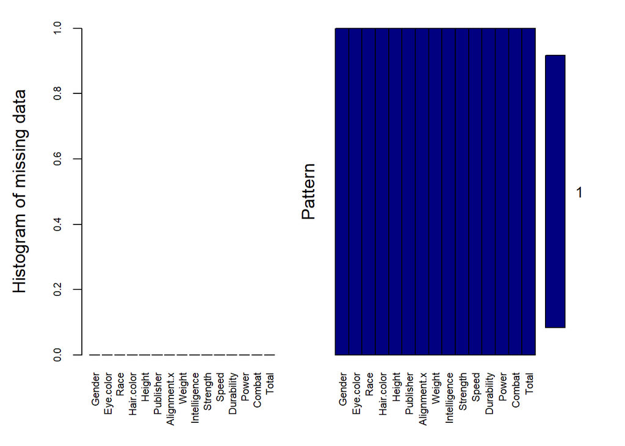

```
##
##  Variables sorted by number of missings:
##      Variable Count
##        Gender     0
##     Eye.color     0
##          Race     0
##    Hair.color     0
##        Height     0
##     Publisher     0
##   Alignment.x     0
##        Weight     0
##  Intelligence     0
##      Strength     0
##         Speed     0
##    Durability     0
##         Power     0
##        Combat     0
##         Total     0
```

```r
aggr_plot <- aggr(Dc_Marvel_StatsInfo, col=c('navyblue','turquoise'), numbers=TRUE, sortVars=TRUE, labels=names(Dc_Marvel_StatsInfo),
                  cex.axis=.7, gap=3, ylab=c("Histogram of missing data","Pattern"))
```

# Análisis exploratorio de los datos de la compañia Marvel

A continuación se observa que las variables “Height”, “Weight”, “Strenght” y “Speed” cuentan con datos con sesgo positivo, ya que hay valores extremos en dirección positiva.

```r
summary(Marvel_StatsInfo, na.rm = TRUE)
```

```
##     Gender           Eye.color             Race            Hair.color
##  Length:379         Length:379         Length:379         Length:379
##  Class :character   Class :character   Class :character   Class :character
##  Mode  :character   Mode  :character   Mode  :character   Mode  :character
##
##
##
##      Height       Publisher         Alignment.x            Weight
##  Min.   : 15.2   Length:379         Length:379         Min.   :  2.0
##  1st Qu.:175.0   Class :character   Class :character   1st Qu.: 61.0
##  Median :183.0   Mode  :character   Mode  :character   Median : 86.0
##  Mean   :189.6                                         Mean   :121.4
##  3rd Qu.:191.0                                         3rd Qu.:117.0
##  Max.   :975.0                                         Max.   :900.0
##   Intelligence       Strength          Speed          Durability
##  Min.   :  1.00   Min.   :  1.00   Min.   :  1.00   Min.   :  1.00
##  1st Qu.:  1.00   1st Qu.:  1.00   1st Qu.:  1.00   1st Qu.:  1.00
##  Median : 50.00   Median : 13.00   Median : 25.00   Median : 42.00
##  Mean   : 45.14   Mean   : 31.54   Mean   : 28.18   Mean   : 44.53
##  3rd Qu.: 69.00   3rd Qu.: 60.00   3rd Qu.: 42.00   3rd Qu.: 80.00
##  Max.   :100.00   Max.   :100.00   Max.   :100.00   Max.   :110.00
##      Power            Combat           Total
##  Min.   :  0.00   Min.   :  1.00   Min.   :  5.0
##  1st Qu.:  0.00   1st Qu.:  1.00   1st Qu.: 19.5
##  Median : 39.00   Median : 56.00   Median :268.0
##  Mean   : 41.28   Mean   : 45.34   Mean   :236.0
##  3rd Qu.: 67.00   3rd Qu.: 70.00   3rd Qu.:355.0
##  Max.   :100.00   Max.   :101.00   Max.   :568.0
```

Ahora se presenta la información de la base de datos de la variable “Intelligence” y observamos que el rango de la variable es [1,100] siendo la inteligencia más frecuente aquella con valor de 1.

```r
Marvel_StatsInfo %>%
  select(Publisher, Intelligence) %>%
  count(Intelligence) %>%
  arrange(desc(Intelligence))
```

```
##    Intelligence   n
## 1           100  18
## 2            88  27
## 3            81   1
## 4            75  46
## 5            69   6
## 6            63  59
## 7            56   5
## 8            55   2
## 9            50  64
## 10           44   2
## 11           38  35
## 12           25   4
## 13           10   5
## 14            8   1
## 15            1 104
```

Luego filtramos la información de la base de datos de la variable “Alignment.x” y observamos que los valores posibles son “neutral”, “good”, “bad” y “Undefined”, siendo la alineación más frecuente “good”.

```r
Marvel_StatsInfo %>%
  select(Publisher, Alignment.x) %>%
  count(Alignment.x) %>%
  arrange(desc(n))
```

```
##   Alignment.x   n
## 1        good 251
## 2         bad 114
## 3     neutral  11
## 4   Undefined   3
```

```r
Marvel_StatsInfo %>%
  select(Publisher, Intelligence, Alignment.x) %>%
  count(Alignment.x, Intelligence) %>%
  arrange(desc(Intelligence))
```

```
##    Alignment.x Intelligence  n
## 1          bad          100  6
## 2         good          100 11
## 3      neutral          100  1
## 4          bad           88 13
## 5         good           88 14
## 6          bad           81  1
## 7    Undefined           75  1
## 8          bad           75 14
## 9         good           75 28
## 10     neutral           75  3
## 11         bad           69  1
## 12        good           69  5
## 13         bad           63 16
## 14        good           63 43
```

[output cut: 21 more lines]

Posterior a ello visualizamos la aseveración previa con el siguiente Box plot.

[figure not shown]

# Plots de gráficos multivariados

## Caritas de Chernoff

A continuación se presenta el gráfico de las caritas de Chernoff para los 11 personajes con “Alignment.x” “neutral” y las variables “Intelligence”, “Strenght”, Speed”, “Durability”, “Power”, y “Combat”

```r
Marvel_StatsInfo %>%
  select(Alignment.x, Intelligence) %>%
  filter(Alignment.x == "neutral") %>%
  arrange(desc(Intelligence))
```

```
##                 Alignment.x Intelligence
## Galactus            neutral          100
## Gladiator           neutral           75
## One-Above-All       neutral           75
## Sentry              neutral           75
## Deadpool            neutral           50
## Red Hulk            neutral           50
## Sandman             neutral           50
## Toad                neutral           50
## Juggernaut          neutral           44
## Copycat             neutral            1
## Living Tribunal     neutral            1
```

Observamos que tres personajes (Red Hulk, Juggernaut y Sandman) presentan rasgos similares (caritas parecidas), sin embargo, el resto de personajes neutrales se encuentran relativamente diferenciados entre sí, siendo Galactus el personaje más sobresaliente.

[figure not shown]

```
## effect of variables:
##  modified item       Var
##  "height of face   " "Height"
##  "width of face    " "Intelligence"
##  "structure of face" "Strength"
##  "height of mouth  " "Speed"
##  "width of mouth   " "Durability"
##  "smiling          " "Power"
##  "height of eyes   " "Combat"
##  "width of eyes    " "Height"
##  "height of hair   " "Intelligence"
##  "width of hair   "  "Strength"
##  "style of hair   "  "Speed"
##  "height of nose  "  "Durability"
##  "width of nose   "  "Power"
##  "width of ear    "  "Combat"
##  "height of ear   "  "Height"
```

```r
faces(Marvel_StatsInfo[Marvel_StatsInfo$Alignment.x=="neutral", c(5,9:14)],
      nrow.plot = 3,
      ncol.plot = 5,
      main = "Personajes Neutrales", print.info = TRUE)
```

# Análisis por clusters

Se analizan las varianzas y correlaciones de los datos. Posteriormente se escalan los datos para normalizarlos.

```r
var(data.matrix(Marvel_StatsInfo[,c(5,8:14)]))
```

```
##                 Height     Weight Intelligence  Strength    Speed Durability
## Height       4356.9656  1153.1394     257.5596  492.6397 166.8985   455.1869
## Weight       1153.1394 12279.2115     358.5133 1339.4261 322.9788  1123.9671
## Intelligence  257.5596   358.5133    1016.3852  567.4771 487.3339   785.4687
## Strength      492.6397  1339.4261     567.4771 1059.0903 481.0930   904.6147
## Speed         166.8985   322.9788     487.3339  481.0930 594.9870   593.8895
## Durability    455.1869  1123.9671     785.4687  904.6147 593.8895  1299.3982
## Power         324.2478   292.6674     824.7008  648.2158 537.9657   885.3950
## Combat        231.2535   393.6994     801.3763  569.6146 474.1099   792.2469
##                  Power    Combat
## Height        324.2478  231.2535
## Weight        292.6674  393.6994
## Intelligence  824.7008  801.3763
## Strength      648.2158  569.6146
## Speed         537.9657  474.1099
## Durability    885.3950  792.2469
## Power        1164.7916  744.6900
## Combat        744.6900 1072.3927
```

```r
cor.mat_all <- cor(data.matrix(Marvel_StatsInfo[,c(5,8:14)]), use="complete.obs")
cor.mat_all
```

```
##                 Height     Weight Intelligence  Strength     Speed Durability
## Height       1.0000000 0.15765382    0.1223930 0.2293353 0.1036589  0.1913051
## Weight       0.1576538 1.00000000    0.1014824 0.3714215 0.1194910  0.2813826
## Intelligence 0.1223930 0.10148245    1.0000000 0.5469564 0.6266770  0.6834844
## Strength     0.2293353 0.37142150    0.5469564 1.0000000 0.6060505  0.7711272
## Speed        0.1036589 0.11949098    0.6266770 0.6060505 1.0000000  0.6754307
## Durability   0.1913051 0.28138260    0.6834844 0.7711272 0.6754307  1.0000000
## Power        0.1439332 0.07738645    0.7579545 0.5836185 0.6462146  0.7196839
## Combat       0.1069841 0.10849323    0.7675919 0.5344877 0.5935378  0.6711390
##                   Power    Combat
## Height       0.14393318 0.1069841
## Weight       0.07738645 0.1084932
## Intelligence 0.75795450 0.7675919
## Strength     0.58361847 0.5344877
## Speed        0.64621463 0.5935378
## Durability   0.71968392 0.6711390
## Power        1.00000000 0.6663071
## Combat       0.66630714 1.0000000
```

```r
DC_M <- scale(Marvel_StatsInfo[,c(5,8:14)])
var(DC_M)
```

```
##                 Height     Weight Intelligence  Strength     Speed Durability
## Height       1.0000000 0.15765382    0.1223930 0.2293353 0.1036589  0.1913051
## Weight       0.1576538 1.00000000    0.1014824 0.3714215 0.1194910  0.2813826
## Intelligence 0.1223930 0.10148245    1.0000000 0.5469564 0.6266770  0.6834844
## Strength     0.2293353 0.37142150    0.5469564 1.0000000 0.6060505  0.7711272
## Speed        0.1036589 0.11949098    0.6266770 0.6060505 1.0000000  0.6754307
## Durability   0.1913051 0.28138260    0.6834844 0.7711272 0.6754307  1.0000000
## Power        0.1439332 0.07738645    0.7579545 0.5836185 0.6462146  0.7196839
## Combat       0.1069841 0.10849323    0.7675919 0.5344877 0.5935378  0.6711390
##                   Power    Combat
## Height       0.14393318 0.1069841
## Weight       0.07738645 0.1084932
## Intelligence 0.75795450 0.7675919
## Strength     0.58361847 0.5344877
## Speed        0.64621463 0.5935378
## Durability   0.71968392 0.6711390
## Power        1.00000000 0.6663071
## Combat       0.66630714 1.0000000
```

```r
dist <- dist(DC_M, method = "euclidean")
head(as.factor(dist))
```

```
##           A-Bomb      Abomination          Abraxas    Absorbing Man
## 2.32025826000226  4.0040891079592 4.66682822353614 5.63469737411371
##         Agent 13        Agent Bob
## 5.07402722714769 4.44499520049926
## 63063 Levels: 0 0.00902432566151012 0.00902432566151018 ... 15.1769908177593
```

Se realizan los clusters

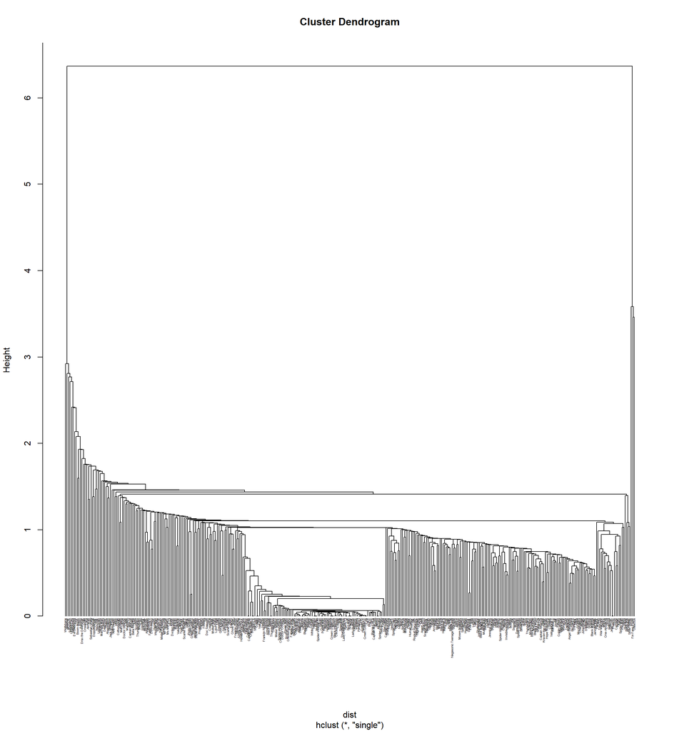

```r
cluster_single <- hclust (d = dist, method = 'single')
plot(cluster_single,cex=0.35, hang = -2)
```

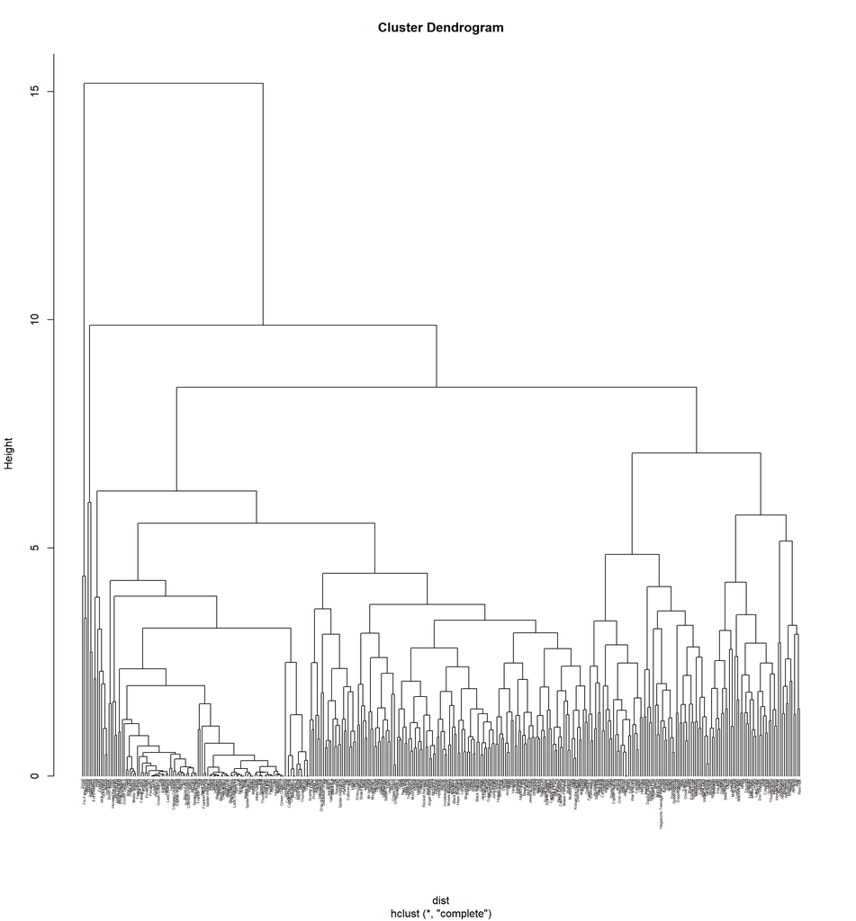

```r
cluster_complete <- hclust (d = dist, method = 'complete')
plot(cluster_complete, cex=0.35, hang = -2)
```

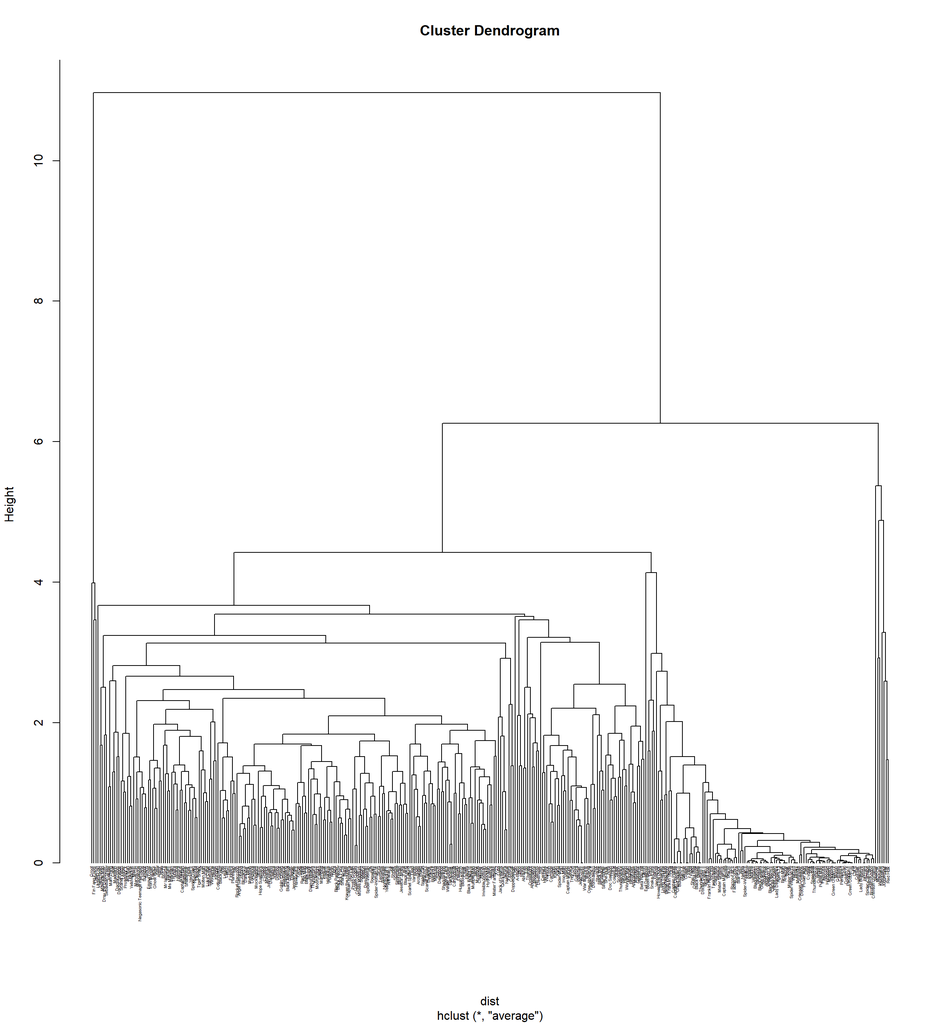

```r
cluster_average <- hclust (d = dist, method = 'average')
plot(cluster_average, cex=0.35, hang = -2)
```

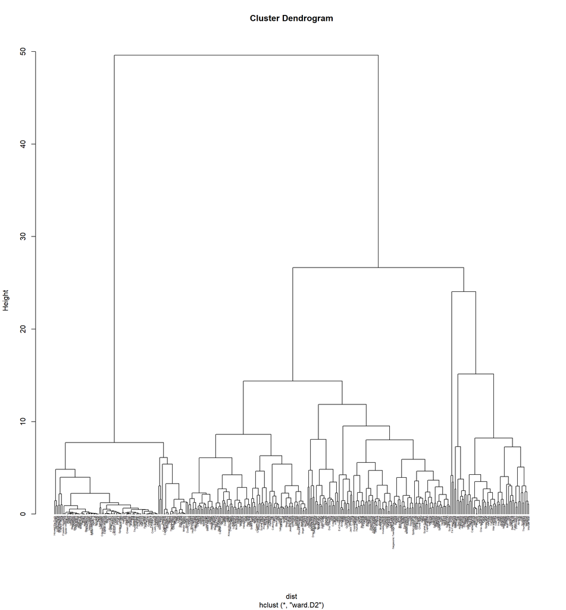

```r
cluster_ward <- hclust (d = dist, method = 'ward.D2')
plot(cluster_ward,cex=0.35, hang = -2)
```

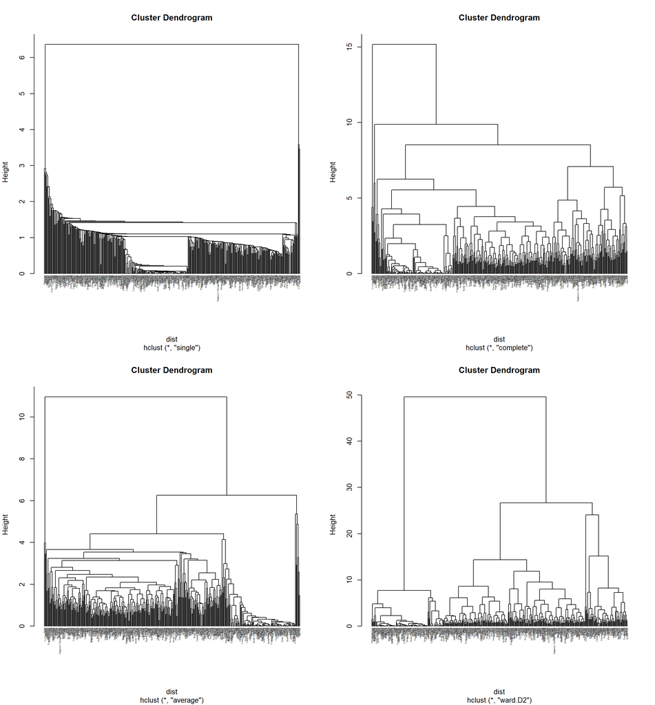

```r
par (mfrow = c(2,2))
plot(cluster_single,cex=0.3, hang = -2, )
plot(cluster_complete,cex=0.3, hang = -2)
plot(cluster_average,cex=0.3, hang = -2)
plot(cluster_ward,cex=0.3, hang = -2)
```

Se calcula y compara el coeficiente de correlación de los métodos

```r
m <- c( "average", "single", "complete", "ward.D2", "median", "centroid")
names(m) <- c( "average", "single", "complete", "ward.D2", "median", "centroid")

coef_cor <- function(x) {
  cor(x=dist, cophenetic(hclust(d=dist, method = x)))
}
```

```r
coef_tabla <- map_dbl(m, coef_cor)
coef_tabla
```

```
##   average    single  complete   ward.D2    median  centroid
## 0.8583606 0.7075658 0.7352691 0.5968621 0.6460318 0.8327798
```

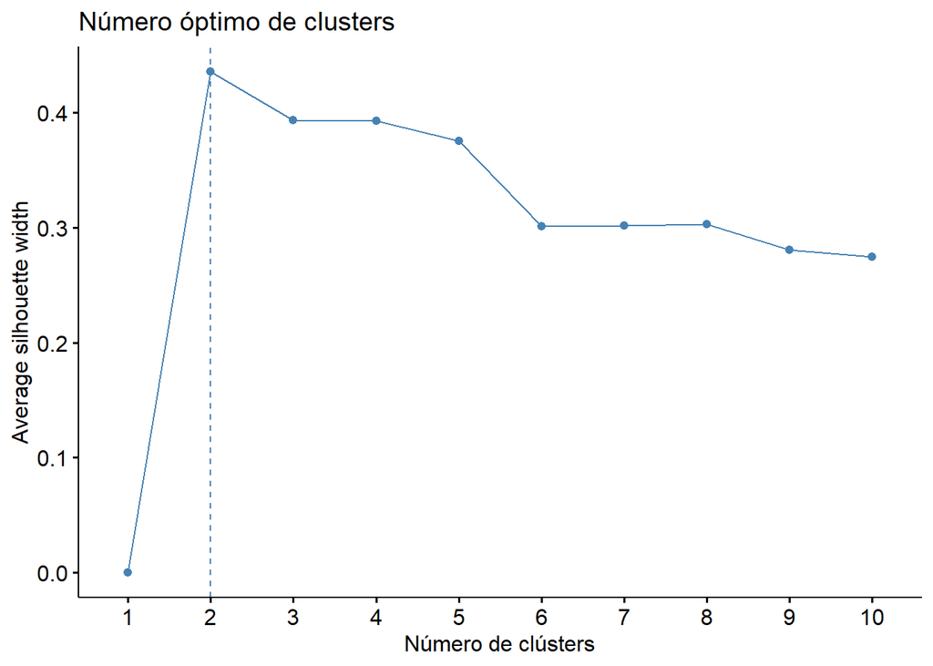

```r
fviz_nbclust(x = DC_M, FUNcluster = hcut, method = "silhouette", diss = dist, k.max = 10) +
  labs(title = "Número óptimo de clusters") +
  xlab("Número de clústers")
```

```r
res.nbclust <- NbClust(DC_M, distance = "euclidean",
                       min.nc = 2, max.nc = 10,
                       method = "average", index ="all")
```

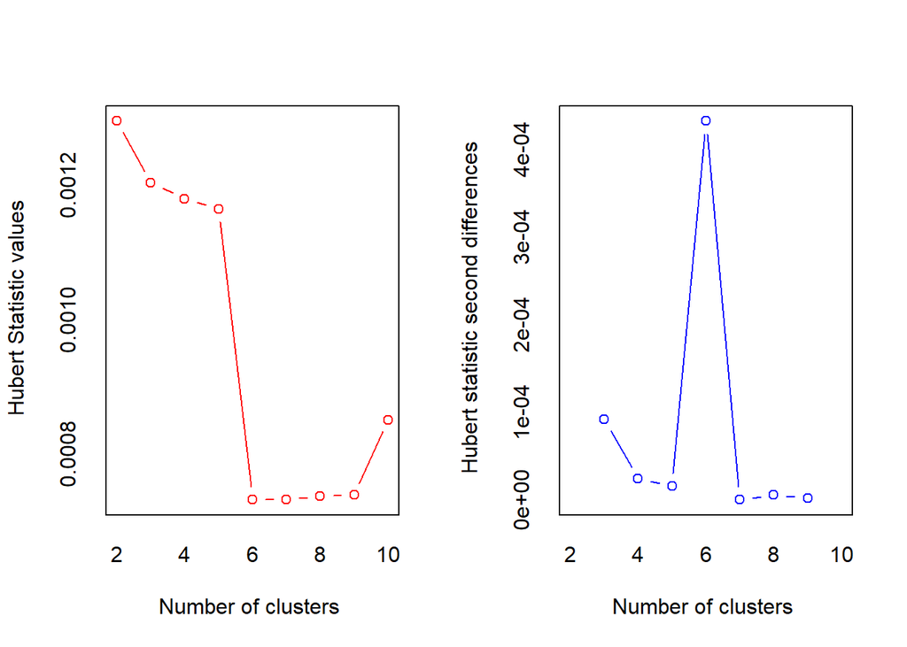

```
## *** : The Hubert index is a graphical method of determining the number of clusters.
##                 In the plot of Hubert index, we seek a significant knee that corresponds to a
##                 significant increase of the value of the measure i.e the significant peak in Hubert
##                 index second differences plot.
##
```

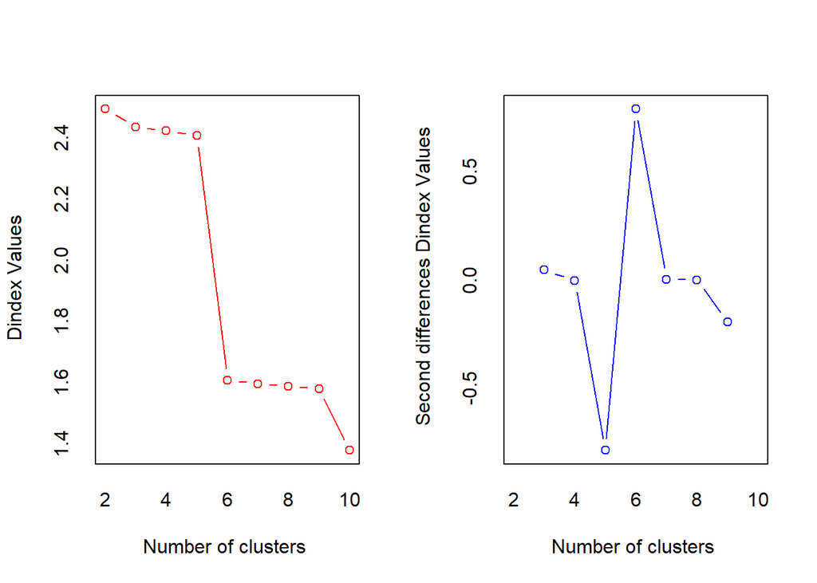

```
## *** : The D index is a graphical method of determining the number of clusters.
##                 In the plot of D index, we seek a significant knee (the significant peak in Dindex
##                 second differences plot) that corresponds to a significant increase of the value of
##                 the measure.
##
## * Among all indices:
## * 8 proposed 2 as the best number of clusters
## * 1 proposed 3 as the best number of clusters
## * 2 proposed 5 as the best number of clusters
## * 9 proposed 6 as the best number of clusters
## * 1 proposed 8 as the best number of clusters
## * 1 proposed 9 as the best number of clusters
## * 2 proposed 10 as the best number of clusters
##
##                    ***** Conclusion *****
##
## * According to the majority rule, the best number of clusters is  6
##
##
```

Una vez obtenidos el método y el número optimos de clusters, realizamos el gráfico implementando la información obtenida.

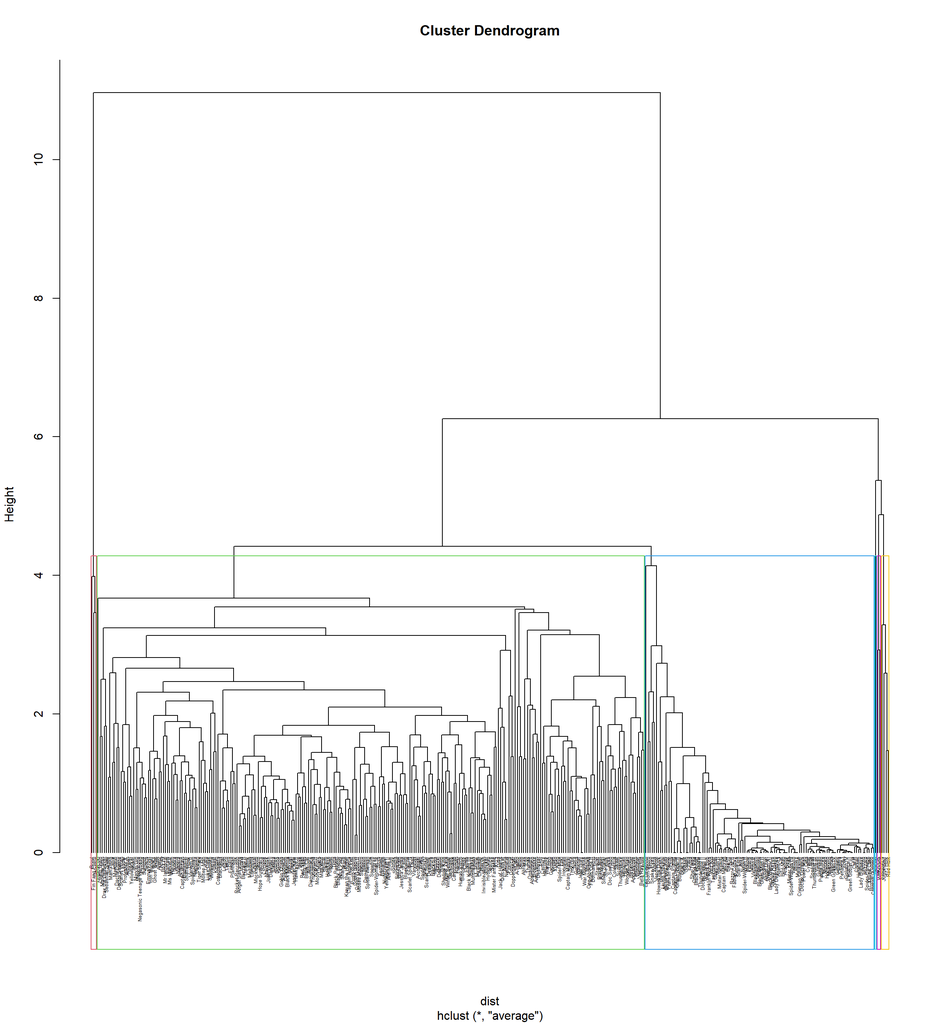

```r
plot(cluster_average, cex = 0.4, hang = -2)
rect.hclust(cluster_average, k = 6, border = 2:8)
```

Haciendo el gráfico de cluster final, obtenemos que, según sus caraterísticas cuantificables, hay dos grupos pincipales de estos, el primero conteniendo más del doble de personajes que el segundo y con los restantes cuatro que se limitan a un máximo de cuatro personajes y un mínimo de uno por grupo.

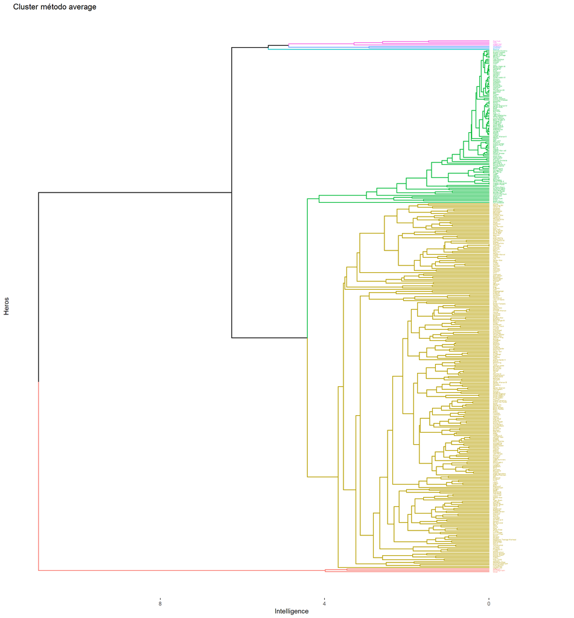

```r
# Clusters
set.seed(12345)
hc_average <- hclust(d=dist, method = "average")

fviz_dend(x = hc_average, k=6,
          cex = 0.2,
          main = "Cluster método average",
          xlab = "Heros",
          ylab = "Intelligence",
          type= "rectangle",
          sub = "",
          horiz = TRUE)
```

```r
sub_grp <- cutree(hc_average, k = 6)
table(sub_grp)
```

```
## sub_grp
##   1   2   3   4   5   6
## 260 109   1   3   4   2
```

# Análisis de PCA

A continuación se realiza un análisis de componentes principales. Realizando una prueba de KMO, observamos que el análisis factorial es más que viable y se grafican las dos componentes con mayor varianza.

```r
kmo.1 <-KMO(Marvel_StatsInfo[,c(5,8:14)])
kmo.1
```

```
## Kaiser-Meyer-Olkin factor adequacy
## Call: KMO(r = Marvel_StatsInfo[, c(5, 8:14)])
## Overall MSA =  0.88
## MSA for each item =
##       Height       Weight Intelligence     Strength        Speed   Durability
##         0.88         0.70         0.86         0.86         0.94         0.87
##        Power       Combat
##         0.90         0.89
```

```r
cp1 <- princomp(Marvel_StatsInfo[,c(5,8:14)], cor = TRUE, scores = TRUE)
summary(cp1)
```

```
## Importance of components:
##                           Comp.1    Comp.2    Comp.3     Comp.4     Comp.5
## Standard deviation     2.0949393 1.0868670 0.9316520 0.70516498 0.59701808
## Proportion of Variance 0.5485963 0.1476600 0.1084969 0.06215721 0.04455382
## Cumulative Proportion  0.5485963 0.6962563 0.8047533 0.86691047 0.91146430
##                           Comp.6     Comp.7     Comp.8
## Standard deviation     0.5622939 0.45618219 0.42896271
## Proportion of Variance 0.0395218 0.02601277 0.02300113
## Cumulative Proportion  0.9509861 0.97699887 1.00000000
```

[figure not shown]

```r
biplot(cp1, col = c("black", "purple"), main = "Marvel_StatsInfo")
```

Del gráfico anterior podemos interpretar que las características de los personajes se dividen en cuatro grupos, de los cuales dos agrupan más de una variable, que son combate con inteligencia, velocidad y poder, así como altura y peso. Haciendo una interpretación de la disposición de las variables, la primer componente describe principalmente las habilidades tanto físicas como intelectuales, mientras que la segunda componente describe los atributos intrínsecos (no modificables) de los personajes

# Conclusiones

De los análisis previos podemos concluir de manera general que la muestra tomada de la población tiende a agruparse según las variables que se consideren, puesto que en general se encuentran considerablemente correlacionadas.